# Happy Monment Analysis

## Word frequency between different group of people. Group or Individual Activity. Category Heatmap. Difference between Verb and Noun

By Zhongce Ji

[figure not shown]

There are many things will make people happy at specific moment in their life. Different group of people will have different perspectives of the happy moments, so for different people the causes of happy moment also differs in some way. So it is interesting to find out what will cause the people happy among different group of people, and let’s compare how they are different from each other!

## Word frequency in happy moment

In order to find out what may cause the happy for different group of people, we use the happy moment data from [HappyDB](https://rit-public.github.io/HappyDB/), and also use the data which has been pre-processed in file Text_Processing.Rmd. In the Text_Processing file, The happy monment text has been cleaned and left some major words. Then we also need to use the data demographic in data folder which contain the demographic data for each happy moment. Then we will compare the word frequency for different group of people according to the demographic data.

### Gender: Female vs Male

To compare what’s the different causes among the female and male, we will create word cloud( only show top 20 frequency word) for both **Female** and **Male**.

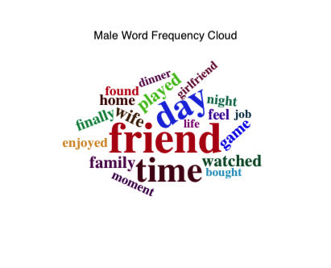

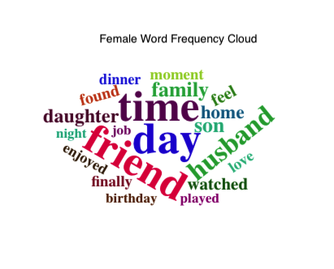

In the word frequency cloud, we can find that The top three word which means the word has highest frequency for both Female and Male is **time**, **day** and **friend**. Then for the male, some words like **girlfriend**, **wife**, **game**, **bought**, **watched** will make them happy. The reason may be for the male, when they did something with their girlfriend or wife will make them happy or when they watch some shows or play some games will also let them have joy. As for the female, word **daughter**, **husband**, **son** and **family** will make them happy, so maybe female will have fun when they spend some times with their family.

### Gender: Married vs Single

Then we are also take look at the difference between **Married People** and **Signle Person**

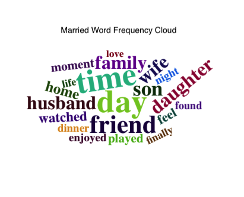

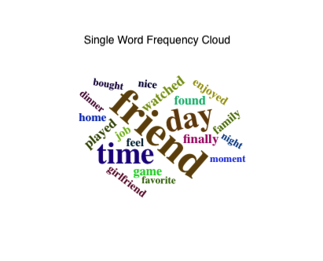

In both word frequency cloud, we find that there are many difference between married people and single person. For the married people, the most frequency word including **time**, **family**, **love**, **wife**, **husband**, **son**, **daughter** which are mostly related to the family so that we may can conclude that people who get married will have most happy moment with their family. While for people who did not get married, the most frequency words including **friend**, **watched**, **game**, **bought** are more likely can be described as less family stuff since watched something or games can also be done with their friends.

### Gender: Parenthood vs No Parenthood

The difference between **Parenthood People** and **No Parenthood people** are also very big.

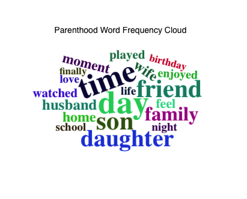

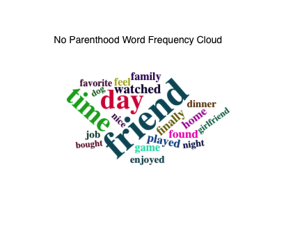